# Text Mining with R Practice

# Overview

This chapter covers relationships between works using n-grams. In this chapter we learn about two new packages, ggraph and widyr. ggraph extends ggplot2 to build network plots. widyr calculates distances between pairs within a tidy dataframe.

First, let’s load the required libraries. If these libraries have not previously installed, uncomment the first lines of the codeblock to install them.

```r
# install.packages("dplyr")
# install.packages("tidytext")
# install.packages("janeaustenr")
library(dplyr)
library(tidytext)
library(janeaustenr)
# The code below tokenizes the works of Jane Austen into n-gram pairs
austen_bigrams <- austen_books() %>%
  unnest_tokens(bigram, text, token = "ngrams", n = 2)
austen_bigrams
```

| book | bigram |
| --- | --- |
| Sense & Sensibility | sense and |
| Sense & Sensibility | and sensibility |
| Sense & Sensibility | sensibility by |
| Sense & Sensibility | by jane |
| Sense & Sensibility | jane austen |
| Sense & Sensibility | austen 1811 |
| Sense & Sensibility | 1811 chapter |
| Sense & Sensibility | chapter 1 |
| Sense & Sensibility | 1 the |
| Sense & Sensibility | the family |

[output cut: 990 more lines]

Now, let’s look at what we have.

```r
austen_bigrams %>%
  count(bigram, sort = TRUE)
```

| bigram | n |
| --- | --- |
| of the | 3017 |
| to be | 2787 |
| in the | 2368 |
| it was | 1781 |
| i am | 1545 |
| she had | 1472 |
| of her | 1445 |
| to the | 1387 |
| she was | 1377 |
| had been | 1299 |

[output cut: 990 more lines]

There are a lot of stop words here that detract from seeing meaningful relationships. We can use the following code to first separate our bi-grams into two columns, using the separate() function, and then remove any pairs of words where either one of the wors ar stop words.

```r
library(tidyr)
bigrams_separated <- austen_bigrams %>%
  separate(bigram, c("word1", "word2"), sep = " ")
bigrams_filtered <- bigrams_separated %>%
  filter(!word1 %in% stop_words$word) %>%
  filter(!word2 %in% stop_words$word)
# new bigram counts:
bigram_counts <- bigrams_filtered %>%
  count(word1, word2, sort = TRUE)
bigram_counts
```

| word1 | word2 | n |
| --- | --- | --- |
| sir | thomas | 287 |
| miss | crawford | 215 |
| captain | wentworth | 170 |
| miss | woodhouse | 162 |
| frank | churchill | 132 |
| lady | russell | 118 |
| lady | bertram | 114 |
| sir | walter | 113 |
| miss | fairfax | 109 |
| colonel | brandon | 108 |

[output cut: 990 more lines]

We can also do the same thing with trigrams. In this code example, we tokenize the works of Jane Austen into trigrams, separate those trigrams into three columns of words, filter those words against the stop word list, and then count our remaining trigram.

```r
austen_books() %>%
  unnest_tokens(trigram, text, token = "ngrams", n = 3) %>%
  separate(trigram, c("word1", "word2", "word3"), sep = " ") %>%
  filter(!word1 %in% stop_words$word,
         !word2 %in% stop_words$word,
         !word3 %in% stop_words$word) %>%
  count(word1, word2, word3, sort = TRUE)
```

| word1 | word2 | word3 | n |
| --- | --- | --- | --- |
| dear | miss | woodhouse | 23 |
| miss | de | bourgh | 18 |
| lady | catherine | de | 14 |
| catherine | de | bourgh | 13 |
| poor | miss | taylor | 11 |
| sir | walter | elliot | 11 |
| ten | thousand | pounds | 11 |
| dear | sir | thomas | 10 |
| twenty | thousand | pounds | 8 |
| replied | miss | crawford | 7 |

[output cut: 990 more lines]

What are the most common streets mentioned in Jane Austen? In this part, we use our previously created list of bigrams, separated and filtered against the stopword list, and then filtered again for pairs of words where the second word is ‘street’.

```r
bigrams_filtered %>%
  filter(word2 == "street") %>%
  count(book, word1, sort = TRUE)
```

| book | word1 | n |
| --- | --- | --- |
| Sense & Sensibility | berkeley | 16 |
| Sense & Sensibility | harley | 16 |
| Northanger Abbey | pulteney | 14 |
| Northanger Abbey | milsom | 11 |
| Mansfield Park | wimpole | 10 |
| Pride & Prejudice | gracechurch | 9 |
| Sense & Sensibility | conduit | 6 |
| Sense & Sensibility | bond | 5 |
| Persuasion | milsom | 5 |
| Persuasion | rivers | 4 |

[output cut: 24 more lines]

```r
bigrams_united <- bigrams_filtered %>%
  unite(bigram, word1, word2, sep = " ")
bigram_tf_idf <- bigrams_united %>%
  count(book, bigram) %>%
  bind_tf_idf(bigram, book, n) %>%
  arrange(desc(tf_idf))
bigram_tf_idf
```

| book | bigram | n | tf | idf | tf_idf |
| --- | --- | --- | --- | --- | --- |
| Persuasion | captain wentworth | 170 | 0.0298559888 | 1.7917595 | 0.0534947506 |
| Mansfield Park | sir thomas | 287 | 0.0287316048 | 1.7917595 | 0.0514801249 |
| Mansfield Park | miss crawford | 215 | 0.0215236760 | 1.7917595 | 0.0385652504 |
| Persuasion | lady russell | 118 | 0.0207235687 | 1.7917595 | 0.0371316504 |
| Persuasion | sir walter | 113 | 0.0198454514 | 1.7917595 | 0.0355582754 |
| Emma | miss woodhouse | 162 | 0.0170096598 | 1.7917595 | 0.0304772190 |
| Northanger Abbey | miss tilney | 82 | 0.0159440016 | 1.7917595 | 0.0285678158 |
| Sense & Sensibility | colonel brandon | 108 | 0.0150208623 | 1.7917595 | 0.0269137723 |
| Emma | frank churchill | 132 | 0.0138597228 | 1.7917595 | 0.0248332896 |
| Pride & Prejudice | lady catherine | 100 | 0.0138045279 | 1.7917595 | 0.0247343936 |

[output cut: 990 more lines]

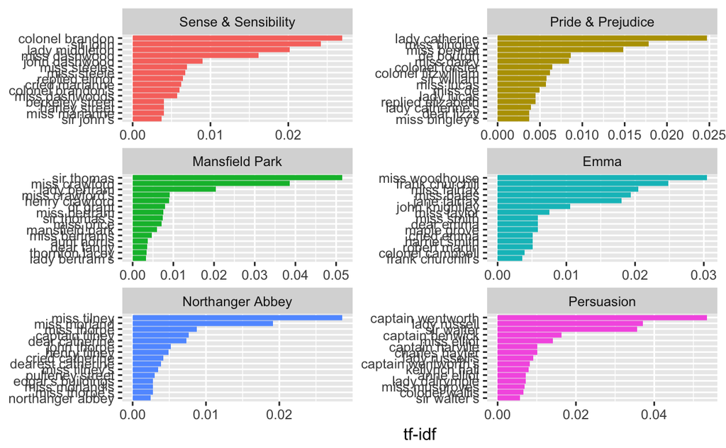

```r
library(ggplot2)
bigram_tf_idf %>%
  arrange(desc(tf_idf)) %>%
  mutate(bigram = factor(bigram, levels = rev(unique(bigram)))) %>% group_by(book) %>%
  top_n(15) %>%
  ungroup %>%
  ggplot(aes(bigram, tf_idf, fill = book)) + geom_col(show.legend = FALSE) +
  labs(x = NULL, y = "tf-idf") +
  facet_wrap(~book, ncol = 2, scales = "free") + coord_flip()
```